# Bike Sharing Analysis with Ford GoBike Data

## by Amira Tantawy

## introduction

Ford GoBike is a regional public bicycle sharing system in the San Francisco Bay Area, California. Beginning operation in August 2013 as Bay Area Bike Share, the Ford GoBike system currently has over 2,600 bicycles in 262 stations across San Francisco, East Bay and San Jose. On June 28, 2017, the system officially launched as Ford GoBike in a partnership with Ford Motor Company.

Ford GoBike, like other bike share systems, consists of a fleet of specially designed, sturdy and durable bikes that are locked into a network of docking stations throughout the city. The bikes can be unlocked from one station and returned to any other station in the system, making them ideal for one-way trips. The bikes are available for use 24 hours/day, 7 days/week, 365 days/year and riders have access to all bikes in the network when they become a member or purchase a pass.

## Age distribution for ford bike riders

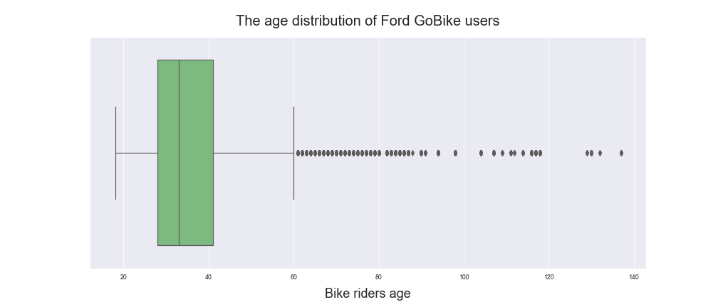

### What is the structure of your dataset?

> it contains 18 columns and 2252057 rows.

### What is/are the main feature(s) of interest in your dataset?

> it contains start and end points also the gender through the period from 2017-2018

### What features in the dataset do you think will help support your investigation into your feature(s) of interest?

> the gender column and member birth year.

## Univariate Exploration

> In this section, investigate distributions of individual variables. If you see unusual points or outliers, take a deeper look to clean things up and prepare yourself to look at relationships between variables.

## Monthly trend of bike riders

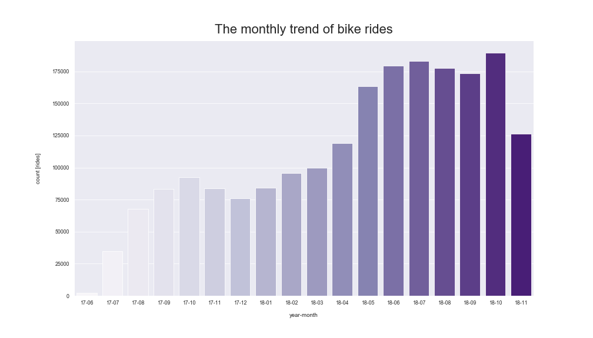

#### we can see that bike sharing reaches it's peak in october then july.

#### also it's trending in summer months more than winter maybe because the good weather.

#### we can also notice that GoBike is getting more popular in 2018 than 2017.

### Bike rides per gender

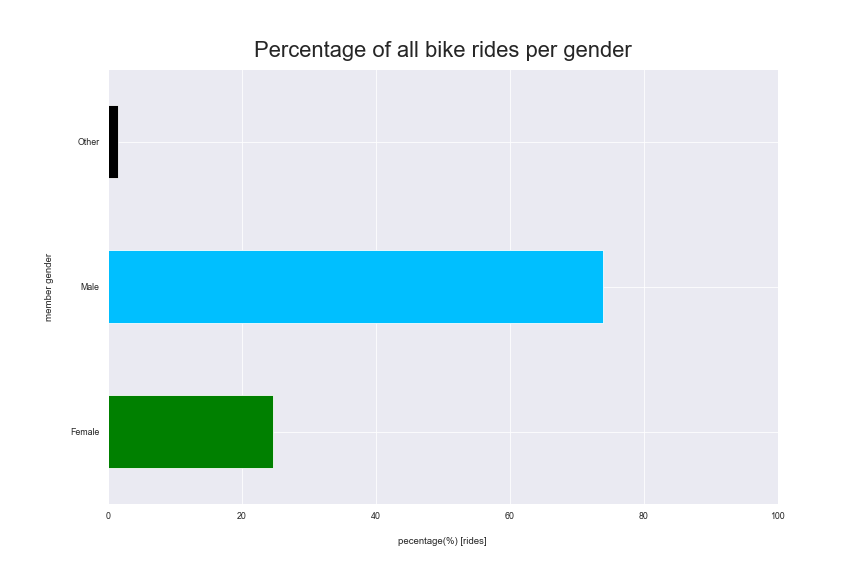

### Bike rides per weekdays

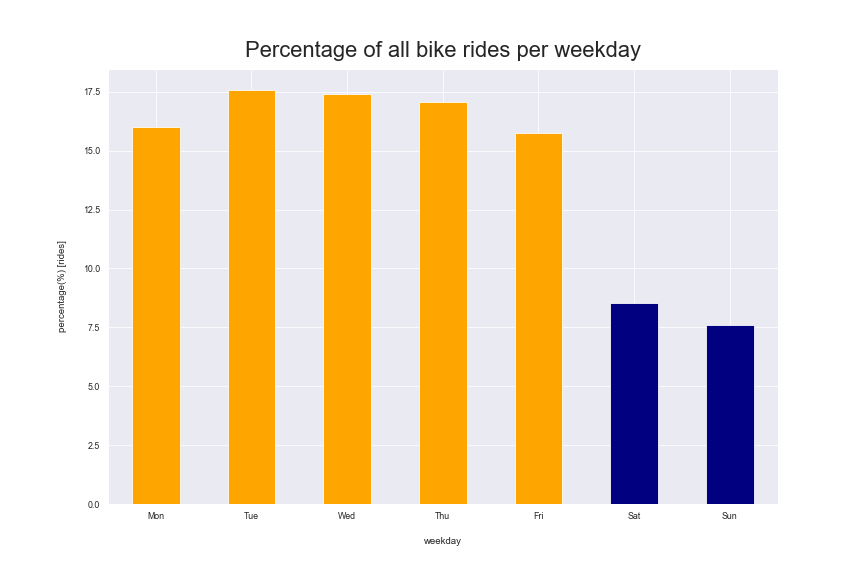

### Of the features you investigated, were there any unusual distributions? Did you perform any operations on the data to tidy, adjust, or change the form of the data? If so, why did you do this?

> The member birth year, which in some cases was dated before 1900. Since 95% of the members are between 17 and 57 years, I removed users older than 60.

## Bivariate Exploration

> Here I'll add customer type to the analysis.

## User trends of bike rides of subscribers vs customers

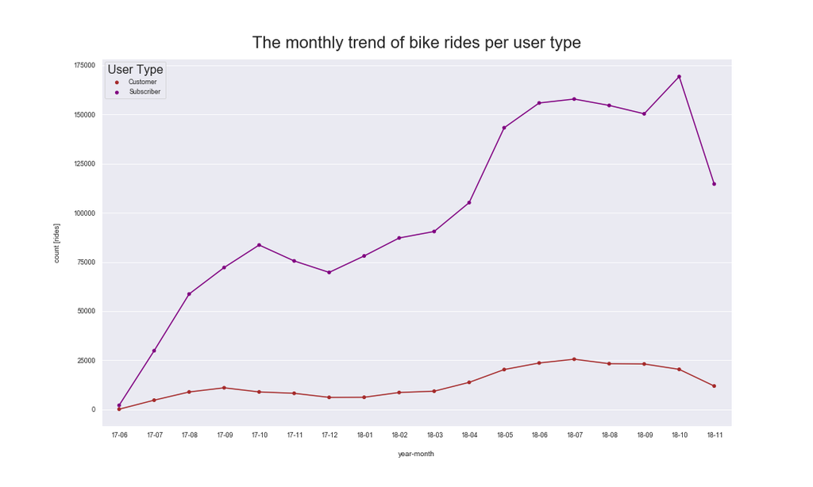

### Average trip duration of subscribers vs customers

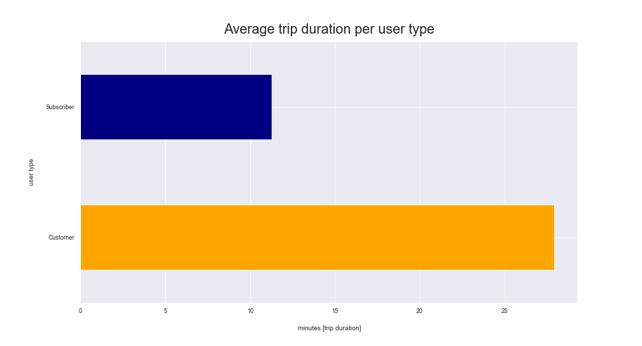

### we can see that customers average trip duration is around 28 minutes and more than subscripers average trip duration which is around 11 minutes.

## User type propotion

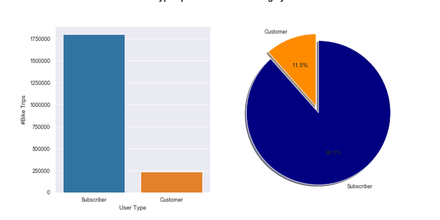

Subscribers are way more than occasional users in this activity.

### Talk about some of the relationships you observed in this part of the investigation. How did the feature(s) of interest vary with other features in the dataset?

when we added the user type to our analysis we can detect different behaviours. as we can see customers number is less than subscribers who is daily coommuters.

## Multivariate Exploration

> Now I'm adding gender to customer type for analysis.

## Split by user type and gender

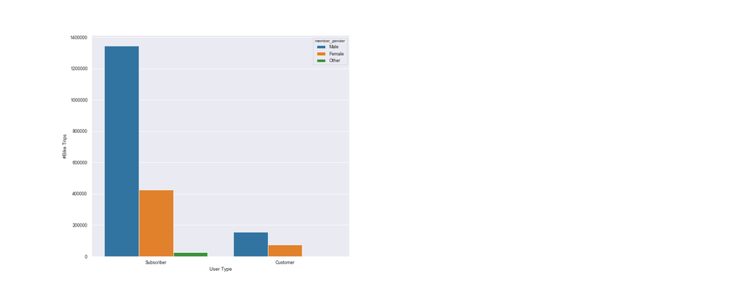

we can see that men are participating in this activity more than women.

## Effects of age group,weekdays and hours on bike rides.

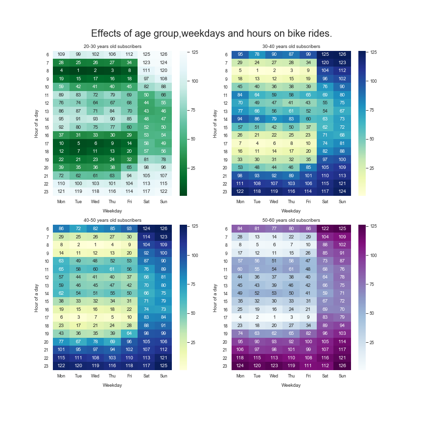